# Reporte t??cnico

```r
directorio <- "/Users/IMEJIAF/proyectoEA1"
setwd(directorio)
```

# Introducci??n

La diabetes mellitus tipo dos es una de las enfermedades definitorias de la sociedad moderna occidental. Se trata de un trastorno metab??lico que inhibe la creaci??n y tolerancia normal a la insulina en sangre, causando episodios de hipoglucemia peligrosos. Daba su naturaleza cr??nica y el tipo de tratamiento que requiere, es indispensable saber en d??nde hay brotes de diabetes para poder responder con pol??ticas de salud p??blica adecuadas.

## Base de datos

Nuestra base de datos de trabajo, descargada en forma de 99 archivos pdf del portal de la Secretar??a de Salud (SSA) comprende informaci??n anual, desde 2003 a 2013. Cada una de las noventa y nueve tablas descargadas contiene de s?? el a??o, g??nero y entidad federativa de las observaciones; mientras existen tres categor??as para diferenciar los mismos:

1. Por fuente de notificaci??n
2. Por mes de observaci??n
3. Por grupo de edad

# Definici??n del problema

Una vez descargados (en una misma carpeta en zip) las 99 tablas guardadas como pdf, procedimos a convertir cada archivo a csv. Usamos el *software* “Nitro” para converitir cada tabla a formato xlsx y despu??s convertimos manualmente cada una a formato csv. De paso eliminamos de cada tabla la columna y rengl??n de total por considerarla informaci??n redundante al an??lisis adem??s de f??cilmente recuperable en R. En algunas tablas (las que la ten??an), eliminamos la variable de incidencia (casos por cien mil habitantes en la entidad federativa) y de tasa (tasa de poblaci??n femenina por entidad federativa) por las mimsas razones que la anterior.

M??s all?? de la conversi??n de los archivos, el problema principal radica en poder analizar e interpretar los datos para encontrar la historia que se esconde en ellos y poder comunicarla construyendo una narrativa adecuada. Nos interesa saber el comportamiento de la diabetes a nivel nacional; en d??nde y cu??do hay m??s casos, en qu?? grupos pobacionales, en qu?? a??os. Cualquier cosa que salte como inesperada ser?? analizada para intentar hallar una explicaci??n a los fen??menos contenidos en la informaci??n que se nos porporcion??.

El objetivo principal es identificar patrones en los datos de diabetes a nivel nacional que permitan a la SSA atender mejor a sus pacientes y dise??ar mejores pol??ticas para combatir este trastorno; esperamos poder evidenciar de manera clara, comparable, reproducible, bien documentada y coherente esa historia.

# Obtenci??n y descripci??n de los datos

Cargamos cada uno de los noventa y nueva archivos en formato csv a R. Usamos la misma nomenclatura con que fueron descargados, donde el archivo “f-f_2005” son las observaciones por fuente de notifiaci??n, femeninas, para el a??o 2005. El primer caracter codifica el tipo de tabla (“f” - por fuente de notificaci??n, “g” - por grupo de edad, “m” - por mes), el tercero el g??nero (“f” - femenino, “m - masculino”, “g” - general, entendido como la suma de observaciones femeninas y masculinas, sujeto a posterior validaci??n) y los ??ltimos cuatro caracteres el a??o. Tenemos treinta y tres tablas de cada tipo, que se ven de la siguiente manera:

```r
head(get("f_m-2009"))
```

```
##                 Estado   Salud IMSS.ORD ISSSTE IMSS.OP   DIF PEMEX SEDENA
## 1      Aguascalientes     578      564    175     S/R    15   S/R      58
## 2     Baja California   1 666    3 295    285      64   S/R   S/R      14
## 3 Baja California Sur     248      725     70     S/R   S/R   S/R       0
## 4            Campeche     356      327     85      69     8     2       4
## 5            Coahuila     500    3 163    755     143     5   S/R      16
## 6              Colima     386      489     23     S/R     0   S/R       0
##   SEMAR  Otras
## 1  S/R      84
## 2    0     515
## 3   12     S/R
## 4   11      10
## 5  S/R   2 067
## 6    8      27
```

```r
head(get("g_m-2009"))
```

```
##                 Estado X..1 X1...4 X5...9 X10...14 X15...19 X20...24
## 1       Aguascalientes    0      0      0        0        0        1
## 2      Baja California    2      1      0        9       14       82
## 3 Baja California  Sur    0      0      0        0        1       11
## 4             Campeche    0      0      0        0        2        2
## 5             Coahuila    0      2      0        4        9       89
## 6               Colima    0      0      0        0        0        3
##   X25...44 X45...49 X50...59 X60...64 X65.y.. Ign.
## 1     399      252      391      170     261     0
## 2   1 330      721    1 657      805   1 204    14
## 3     342      124      292      112     172     1
## 4     226      168      244      120     110     0
## 5   1 211      938    1 836    1 070   1 355   135
## 6     228      135      276      117     174     0
```

```r
head(get("m_m-2009"))
```

```
##                 Estado    Ene    Feb    Mar    Abr    May    Jun    Jul
## 1     Baja California    420    411    597    389    418    555    490
## 2 Baja California Sur     93     93    114     71     87    105     80
## 3            Campeche     73     59     94     46     70     88     40
## 4            Coahuila    645    529    684    439    508    644    484
## 5              Colima     78     51    109     66     61     91     60
## 6             Chiapas    371    405    429    393    386    461    280
##      Ago    Sep    Oct    Nov   Dic
## 1   499    574    520    502    464
## 2    73     98     69     93     79
## 3    66    110     81     69     76
## 4   516    636    503    454    607
## 5   103    102     83     73     56
## 6   393    370    326    310    268
```

# Transformaci??n de los datos

## Formato

A cada *data frame* le aplicamos la func??n melt(), de reshape2, para pasar al formato largo.

Nuestra estructura ahora se ve as??:

```r
head(get("f_m-2009"))
```

```
##                 Estado fuente observaciones
## 1      Aguascalientes   Salud          578
## 2     Baja California   Salud        1 666
## 3 Baja California Sur   Salud          248
## 4            Campeche   Salud          356
## 5            Coahuila   Salud          500
## 6              Colima   Salud          386
```

## Agregamos columnas

Para poder unir nuestras tablas sin perder informaci??n, agregamos a cada una una columna con el a??o (2003:2013) y otra con el g??nero (“femenino”, “masculino” y “general”).

Ahora as?? se ve cada una:

```r
head(get("f_m-2009"))
```

```
##                 Estado fuente observaciones  ano    genero
## 1      Aguascalientes   Salud          578  2009 masculino
## 2     Baja California   Salud        1 666  2009 masculino
## 3 Baja California Sur   Salud          248  2009 masculino
## 4            Campeche   Salud          356  2009 masculino
## 5            Coahuila   Salud          500  2009 masculino
## 6              Colima   Salud          386  2009 masculino
```

## Agrupaci??n de los datos

Si los datos fueran ideales; es decir, se adirieran a la definici??n de *tidy data*, podr??amos unir todos en una sola table donde cada rengl??n fuera una observaci??n y cada coulmna una variable. Desgraciadamente, los datos de la SSA no cumplen esta definici??n pues resulta imposible encontrar una relaci??n uno a uno entre los datos que se encuentran en distintos tipos de tablas. Esto es que no sabemos en d??nde fue noificado un caso que se di?? en enero, ni en qu?? grupo de edad se encuentra.

Por esto, nos quedamos con tres unidades observacionales; fuente, grupo y mes, y unimos cada subconjnto de treinta y tres tablas en tres grandes tablas llamadas fuente, grupo y mes.

Ahora, contamos con la siguiente estrucutra:

```r
str(fuente)
```

```
## 'data.frame':    9504 obs. of  5 variables:
##  $ Estado       : chr  "Aguascalientes " "Baja California " "Baja California Sur " "Campeche " ...
##  $ fuente       : Factor w/ 15 levels "Salud","IMSS.ORD",..: 1 1 1 1 1 1 1 1 1 1 ...
##  $ observaciones: chr  "  690 " " 2 303 " "  371 " "  321 " ...
##  $ ano          : int  2013 2013 2013 2013 2013 2013 2013 2013 2013 2013 ...
##  $ genero       : Factor w/ 3 levels "masculino","general",..: 1 1 1 1 1 1 1 1 1 1 ...
```

```r
str(grupo)
```

```
## 'data.frame':    12672 obs. of  5 variables:
##  $ Estado       : chr  "Aguascalientes" "Baja California" "Baja California Sur" "Campeche" ...
##  $ grupo        : Factor w/ 15 levels "X..1","X1...4",..: 1 1 1 1 1 1 1 1 1 1 ...
##  $ observaciones: chr  "N.A. " "N.A. " "N.A. " "N.A. " ...
##  $ ano          : int  2013 2013 2013 2013 2013 2013 2013 2013 2013 2013 ...
##  $ genero       : Factor w/ 3 levels "masculino","general",..: 1 1 1 1 1 1 1 1 1 1 ...
```

```r
str(mes)
```

```
## 'data.frame':    12672 obs. of  5 variables:
##  $ Estado       : chr  "Baja California " "Baja California Sur " "Campeche " "Coahuila " ...
##  $ mes          : Factor w/ 24 levels "Ene","Feb","Mar",..: 1 1 1 1 1 1 1 1 1 1 ...
##  $ observaciones: chr  "  643 " "  86 " "  48 " "  475 " ...
##  $ ano          : int  2013 2013 2013 2013 2013 2013 2013 2013 2013 2013 ...
##  $ genero       : Factor w/ 3 levels "masculino","general",..: 1 1 1 1 1 1 1 1 1 1 ...
```

## Limpieza de los datos

Procedemos a limpiar los datos de informaci??n repetida. Para ello suponemos que “SEDEMAR” significa lo mismo que “SEMAR”, agrupamos todas las instancias de “IMMS.Ord” e “IMMS.Op” en un solo “IMMS”, corregimos nombres de estado escritos de diferentes maneras y normalizamos los nombres de cada mes a un solo formato. As??mismo, cambiamos la clase de cada variable, pensando en graficar posteriormente, dejando el a??o y observaciones como *int* y el resto como *factor*.

Nos quedamos con la estructura limpia:

```r
str(fuente)
```

```
## 'data.frame':    9504 obs. of  5 variables:
##  $ Estado       : Factor w/ 32 levels "Aguascalientes",..: 1 2 3 4 7 8 5 6 9 10 ...
##  $ fuente       : Factor w/ 8 levels "DIF","IMMS","ISSSTE",..: 8 8 8 8 8 8 8 8 8 8 ...
##  $ observaciones: int  690 2303 371 321 377 317 1800 1709 5136 342 ...
##  $ ano          : int  2013 2013 2013 2013 2013 2013 2013 2013 2013 2013 ...
##  $ genero       : Factor w/ 3 levels "masculino","general",..: 1 1 1 1 1 1 1 1 1 1 ...
```

```r
str(grupo)
```

```
## 'data.frame':    12672 obs. of  5 variables:
##  $ Estado       : Factor w/ 32 levels "Aguascalientes",..: 1 2 3 4 7 8 5 6 9 10 ...
##  $ grupo        : Factor w/ 12 levels "---1","1---4",..: 1 1 1 1 1 1 1 1 1 1 ...
##  $ observaciones: int  NA NA NA NA NA NA NA NA NA NA ...
##  $ ano          : int  2013 2013 2013 2013 2013 2013 2013 2013 2013 2013 ...
##  $ genero       : Factor w/ 3 levels "masculino","general",..: 1 1 1 1 1 1 1 1 1 1 ...
```

```r
str(mes)
```

```
## 'data.frame':    12672 obs. of  5 variables:
##  $ Estado       : Factor w/ 32 levels "Aguascalientes",..: 2 3 4 7 8 5 6 9 10 11 ...
##  $ mes          : Factor w/ 12 levels "Abril","Agosto",..: 4 4 4 4 4 4 4 4 4 4 ...
##  $ observaciones: int  643 86 48 475 81 457 684 1109 219 624 ...
##  $ ano          : int  2013 2013 2013 2013 2013 2013 2013 2013 2013 2013 ...
##  $ genero       : Factor w/ 3 levels "masculino","general",..: 1 1 1 1 1 1 1 1 1 1 ...
```

Que se ve como:

```r
head(fuente)
```

```
##                Estado fuente observaciones  ano    genero
## 1      Aguascalientes    SSA           690 2013 masculino
## 2     Baja California    SSA          2303 2013 masculino
## 3 Baja California Sur    SSA           371 2013 masculino
## 4            Campeche    SSA           321 2013 masculino
## 5            Coahuila    SSA           377 2013 masculino
## 6              Colima    SSA           317 2013 masculino
```

```r
head(grupo)
```

```
##                Estado grupo observaciones  ano    genero
## 1      Aguascalientes  ---1            NA 2013 masculino
## 2     Baja California  ---1            NA 2013 masculino
## 3 Baja California Sur  ---1            NA 2013 masculino
## 4            Campeche  ---1            NA 2013 masculino
## 5            Coahuila  ---1            NA 2013 masculino
## 6              Colima  ---1            NA 2013 masculino
```

```r
head(mes)
```

```
##                Estado   mes observaciones  ano    genero
## 1     Baja California Enero           643 2013 masculino
## 2 Baja California Sur Enero            86 2013 masculino
## 3            Campeche Enero            48 2013 masculino
## 4            Coahuila Enero           475 2013 masculino
## 5              Colima Enero            81 2013 masculino
## 6             Chiapas Enero           457 2013 masculino
```

# Calidad de los datos

## Validaci??nes

### Valores faltantes

Contamos los valores faltantes de la columna observaciones (la ??nica en que pueden existir), en t??rminos absoutos y relativos; es decir, calculamos el total de valores faltantes y el porcentaje que representan del total.

Tenemos: 1. Fuente Valores faltantes:

```
## [1] 1137
```

Porcentaje del total:

```
## [1] 11.96338
```

2. Grupo Valores faltantes:

```
## [1] 285
```

Porcentaje del total:

```
## [1] 2.249053
```

3. Mes Valores faltantes:

```
## [1] 1
```

Porcentaje del total:

```
## [1] 0.007891414
```

### VG??nero

Esperar??amos que el n??mero de observaciones reportadas como masculinas sumadas a las femeninas diera las generales, en todos los casos. Realizamos esta validaci??n para cada a??o y tipo de observaci??n.

Guardamos estos resultados en tres tablas nuevas, que ademas contienen el total y media de observaciones en cada caso.

```
##   fuente hombres mujeres suma_hombres_mujeres general coinciden      media
## 1    SSA  543010  967162              1510172 1510252     FALSE 4290.48864
## 2   IMMS  746457 1035516              1781973 1781973      TRUE 2663.63677
## 3 ISSSTE  284623  371599               656222  656222      TRUE 1864.26705
## 4    DIF   27081   45593                72674   72674      TRUE  277.38168
## 5  PEMEX   11618   12447                24065   24065      TRUE  106.48230
## 6 SEDENA   15344   23155                38499   38499      TRUE  109.68376
## 7  SEMAR    3544    6394                 9938    9938      TRUE   38.82031
## 8  OTRAS  165095  209791               374886  374886      TRUE 1167.86916
```

```
##          grupo hombres mujeres suma_hombres_mujeres general coinciden
## 1         ---1     441     254                  695     695      TRUE
## 2        1---4     379     420                  799     799      TRUE
## 3        5---9     552     613                 1165    1165      TRUE
## 4      10---14    1257    1515                 2772    2772      TRUE
## 5      15---19    3132    5174                 8306    8304     FALSE
## 6      20---24   13405   24602                38007   38004     FALSE
## 7      25---44  376644  569725               946369  946490     FALSE
## 8      45---49  239935  374638               614573  614718     FALSE
## 9      50---59  505329  782654              1287983 1288175     FALSE
## 10     60---64  250533  347598               598131  598398     FALSE
## 11       65---  400208  558083               958291  958584     FALSE
## 12 desconocido    3946    6381                10327   10325     FALSE
##          media
## 1     2.171875
## 2     2.496875
## 3     3.640625
## 4     7.875000
## 5    23.590909
## 6   107.965909
## 7  2688.892045
## 8  1746.357955
## 9  3659.588068
## 10 1699.994318
## 11 2723.250000
## 12   29.332386
```

```
##           mes hombres mujeres suma_hombres_mujeres general coinciden
## 1       Enero  155537  220479               376016  356824     FALSE
## 2     Febrero  146918  217335               364253  344331     FALSE
## 3       Marzo  162361  243224               405585  381278     FALSE
## 4       Abril  151357  226764               378121  356921     FALSE
## 5        Mayo  154779  230850               385629  366042     FALSE
## 6       Junio  158187  240188               398375  373307     FALSE
## 7       Julio  153643  229851               383494  364856     FALSE
## 8      Agosto  153100  231187               384287  365076     FALSE
## 9  Septiembre  145457  218523               363980  341677     FALSE
## 10    Octubre  153230  232176               385406  365653     FALSE
## 11  Noviembre  141303  209349               350652  331943     FALSE
## 12  Diciembre  120551  171731               292282  273925     FALSE
##        media
## 1  1013.7045
## 2   978.2131
## 3  1083.1761
## 4  1013.9801
## 5  1039.8920
## 6  1060.5312
## 7  1036.5227
## 8  1037.1477
## 9   970.6733
## 10 1038.7869
## 11  943.0199
## 12  778.1960
```

## Conjunto de datos ideal

Como se vi?? anteriormente, las validaciones aplicadas a los datos fueron muy insatisfactorias. Se espera consistencia en la informaci??n, que es deficiente. Nuestro conjunto de datos ideal para este problema hubiera pasado nuestras validaciones sin problema alguno, adem??s de haber sido recopilado como un solo conjunto observacional para poder ser analizado en conjunto y llegar a conclusiones a??n m??s poderosas y reveladoras.

Como recomendaci??n para la levantaci??n futura de informaci??n por parte de la SSA est?? el evitar la codificaci??n de valores faltantes (pues pudieron haber reportado cero observaciones en su lugar) y ser cuidadosos para asegurar que coincidan las observaciones generales con las masculians y femeninas. As?? como no reportar sus datos en formato pdf sino csv, para poder ser f??cilmente importados a diversos *softwares* estad??sticos.

# An??lisis exploratorio

```r
#ggplot(mes,aes(x=Estado,y=observaciones,fill=mes))+geom_bar(stat="identity")+facet_wrap(~a??o)+theme(axis.text.x=element_text(angle=90,size=3))+coord_flip()+scale_fill_manual(values=topo.colors(12))
```

## Medias de 2003:2013 por mes

Tomando la media de observaciones por a??o para el periodo de 2003 a 2013, vemos en la siguiente gr??fica que el mes de Marzo es el que tiene m??s casos en promedio. De hecho, parece que los meses m??s calidos (Mayo, Marzo, Junio, Julio, Agosto, Abril) son los ??nios que logran rebasar la media global, con la excepci??n de Octube y Enero.

El mes con menor n??mero de casos en promedio es, por mucho, Diciembre. Esto salta a la vista pues n se espera que la diabetes sea una enfermedad estacional. Probablemente haya otra variable que explique este fen??meno, como en qu?? momento se busca el tratamiento en lugar de en qu?? momento se manifesta el trastorno.

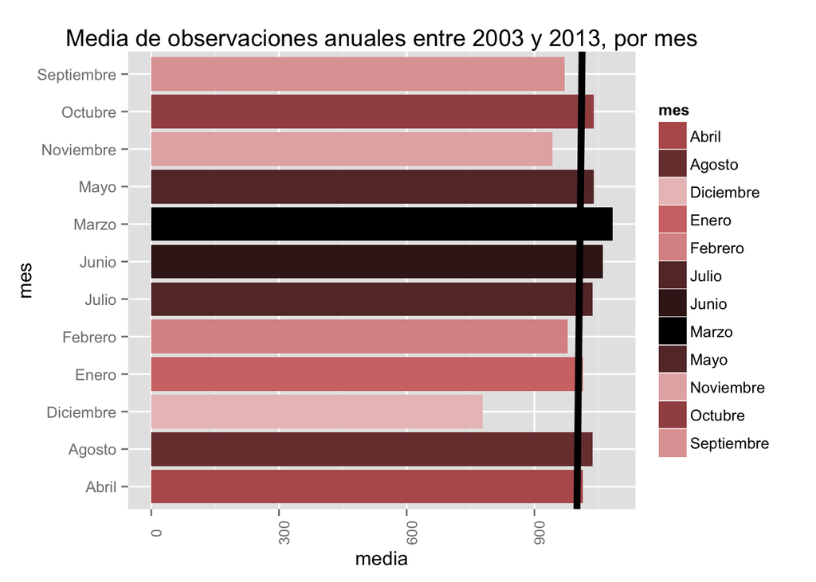

## Medias de 2003:2013 por grupo de edad

Esta gr??fica se observa muy consistente con lo esperado. El grupo que en promedio registra m??s casos en el periodod es el de cinciuenta a cincuenta y nueve a??os. Seguido cercanamente de el de veinticino a cuarenta y cuatro y el de sesenta y cinco en adelante. Es inesperado que en el grupo de sesenta a sesenta y cuatro haya menos casos en promedio que entre los dos que lo rodean (cincuenta a cincuenta y nueve y sesenta y cinco en adelante). Esto se debe posiblemente a que los grupos de edad no comprenden los mismos per??odos de tiempo, dejando que ambos grupos aleda??os al de sesenta a sesenta y cuatro acumulen muchos m??s casos pues abarcan per??odos mucho m??s grandes. Como sugerencia para mejorar el an??lisis a futuro est?? el normalizar los grupos de edad para que comprendan todos per??odos del mismo tiempo; as?? eliminando el sesgo que esto introduce.

No se observan casos significativos hasta despu??s de los veinticinco a??os, pero no podemos saber con exactitud en qu?? edad comienzan la mauor??a de los casos por lo largo de ese grupo, que comprende casi veinte a??os.

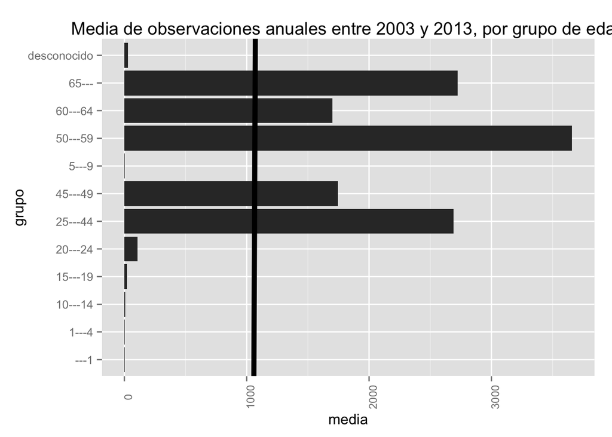

## Media de 2003:2013 por fuente de notificaci??n

Sobresale significativamente la SSA como la mayor fuente de notificaci??n de casos, en promedio. Seguida de IMMS, ISSTE y OTRAS; SEDENA, PEMEX, SEMAR y DIF se encuentran muy por debajo de la media global, probablemente porque se trata se proveedores de servicios de salud que no atienden a la poblaci??n en general sino a grupos especializados.

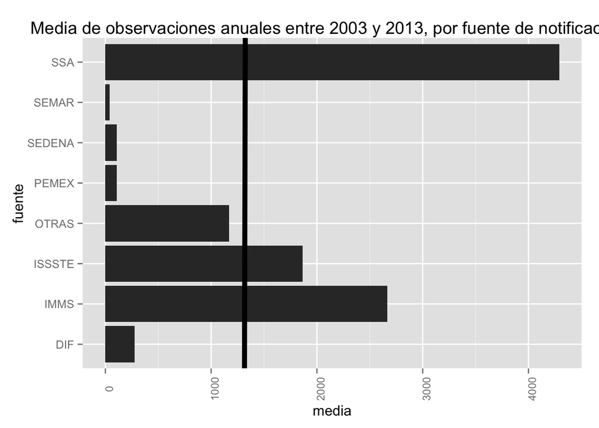